# VHL snRNAseq report

February 24, 2023

All outputs will be saved to out/221202_A01366_0326_AHHTTWDMXY/hg38/SHE5052A9_S101/all-well/DGE_filtered/unintegrated/.

## Load data and filter genes

Load Parse Biosciences split-pipe pipeline output as a Seurat object with no cut-offs, remove any missing samples, add sample metadata, add summary statistics, and optionally subset samples. Then filter nuclei per gene.

Gene-level filtering is also performed at this point, based on the `min_nuclei_per_gene` argument. Genes that are present in very few nuclei of the dataset (e.g., <3) are uninformative and unlikely to help in differentiating between groups of nuclei. In general, most genes removed by this filtering step will be those not detected in any nuclei, which will help to trim the size of the object.

The minimum number of nuclei per gene is set to **5**.

```r
# seu <- load_parse_to_seurat(
#     parse_dir,
#     experiment,
#     genome,
#     sublibrary,
#     parse_analysis_subdir,
#     min_nFeature_RNA = 0,
#     min_nuclei_per_gene = min_nuclei_per_gene,
#     sample_subset,
#     remove_na_samples = T,
#     do_add_sample_metadata = T,
#     do_add_summary_stats = T,
#     groupings
#   )
# # save seu
# saveRDS(seu, file = here::here(out$base, "/seu.rds"))
seu <- readRDS(here::here(out$base, "/seu.rds"))
seu <- seu[sample(nrow(seu), nrow(seu)*0.1),sample(ncol(seu), ncol(seu)*0.1)]
```

## Sample-level overview

Nuclei per sample

```
## Defaulting to continuous.
```

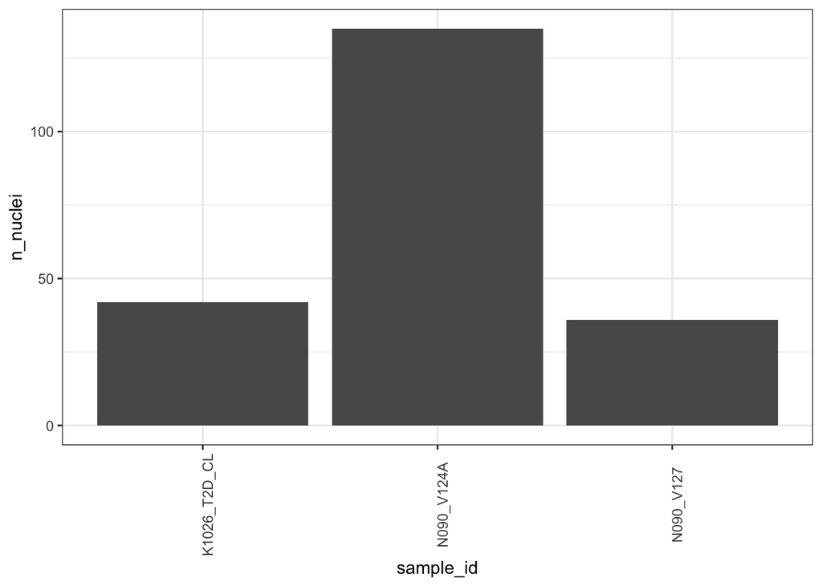

Summary statistics

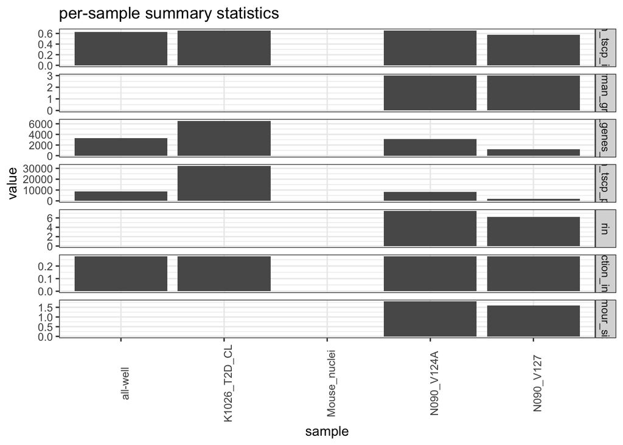

## Filter nuclei

Nucleus-level filtering is performed, applying cut-offs to `nCount_RNA`, `nFeature_RNA`, `percent_mito`, and `doublet` values of each nucleus.

### Annotate doublets

Putative doublets are identified using the `scDblFinder` package. This package creates artificial doublets by grouping together random pairs of nuclei within each sample to create pseudo-doublets, and then identifying nuclei that cluster near to these pseudo-doublets during dimensionality reduction, which means that they carry a doublet signature.

The `remove_doublets` argument is set to **FALSE**.

A dummy column will be introduced, treating all nuclei as though they are singlets.

```r
seu$doublet <- 0
```

### Annotate transcript types

Proportions of transcript types of interest (mitochondrial, ribosomal, globin) are annotated. Mitochondrial genes are particularly of interest for filtering, but it is good practice to inspect the others as well.

- `percent_mito` - See above.
- `percent_ribo` - mRNA that code for ribosomal proteins. They do not point to specific issues, but it can be good to have a look at their relative abundance. They can have biological relevance.
- `percent_globin` - Globin genes are very abundant in erythrocytes. Depending on your application, you can expect ‘contamination’ of erythrocytes and select against it.

```r
  seu <- annotate_proportions_of_transcript_types(seu)
```

### Define nucleus-level filters

The `do_filtering` argument is set to **TRUE**. Filters will be applied.

```r
seu <- get_filters(
  seu,
  do_filtering,
  remove_doublets,
  min_nCount_RNA,
  max_nCount_RNA,
  min_nFeature_RNA,
  max_nFeature_RNA,
  max_percent_mito
)
```

doublet min = 0  
doublet max = 1  
nCount_RNA min = 0  
nCount_RNA max = 3153.7956  
nFeature_RNA min = 100  
nFeature_RNA max = 890.2882  
percent_mito min = 0  
percent_mito max = 0

#### Plot of filters vs feature distribution

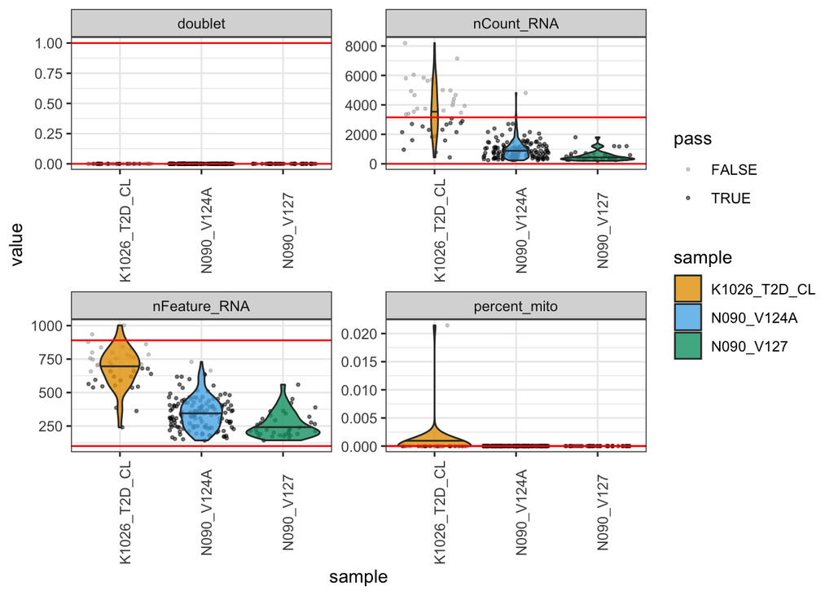

#### Plot of the proportions of filtered nuclei and their fail criteria for each sample

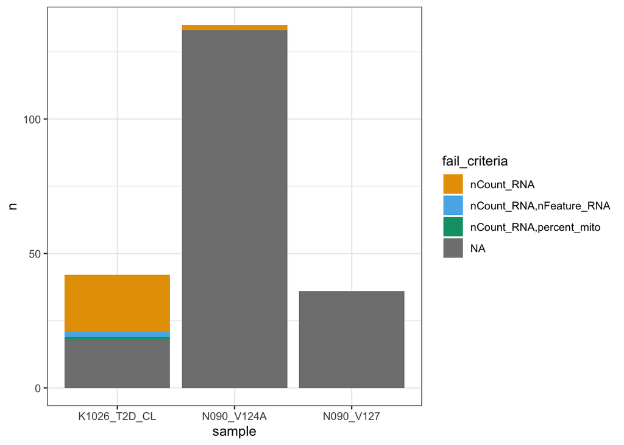

#### Plot of filters vs nucleus scatter

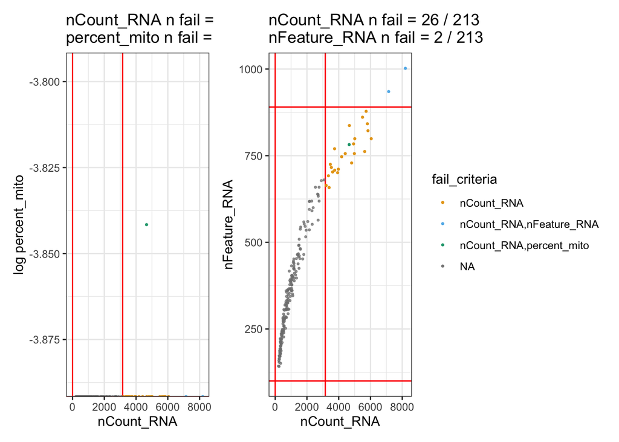

### Apply nucleus-level filters

```r
seu <- subset(seu, cells = unique(dplyr::filter(seu@misc$nucleus_filtering, pass)$nucleus))

# save seu_filtered
saveRDS(seu, here::here(out$base, "seu_filtered.rds"))
```

## Highest variable genes

Find the most highly variable genes (HVGs) across samples.

```r
seu <- Seurat::FindVariableFeatures(seu)
```

#### Plot of HVGs

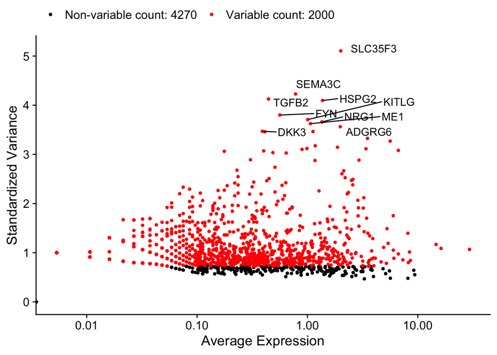

#### Heatmap of top 20 HVGs

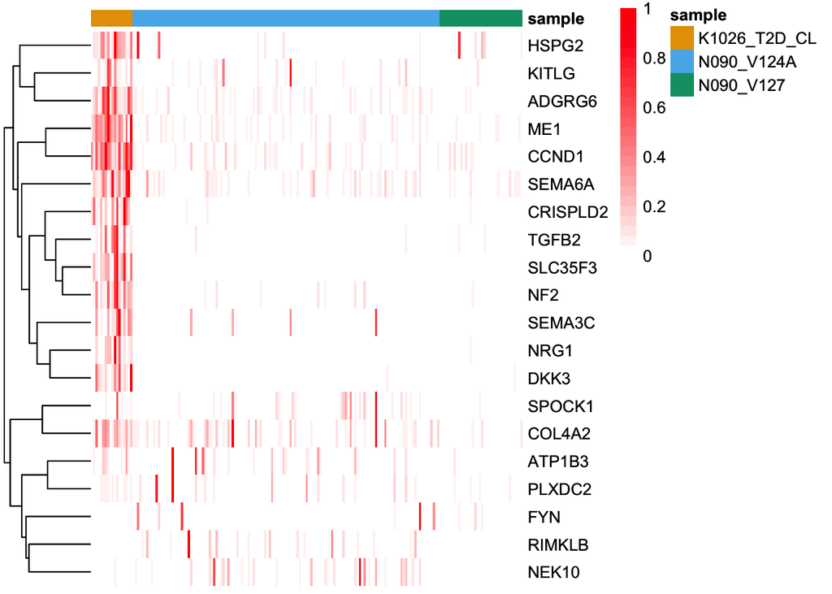

## Normalisation and scaling

Running SCTransform() for normalisation and scaling of the data.

Variables to regress out of the SCTransform residuals are percent_mito, nCount_RNA (argument `vars_to_regress`). This prevents these variables from contributing much to the PCA during dimensionality reduction, and thus confounding the analysis due to irrelevant variation.

```r
seu <- Seurat::SCTransform(seu, vars.to.regress = vars_to_regress)
```

```
## Calculating cell attributes from input UMI matrix: log_umi
```

```
## Variance stabilizing transformation of count matrix of size 1431 by 187
```

```
## Model formula is y ~ log_umi
```

```
## Get Negative Binomial regression parameters per gene
```

```
## Using 1431 genes, 187 cells
```

```
## Found 16 outliers - those will be ignored in fitting/regularization step
```

```
## Second step: Get residuals using fitted parameters for 1431 genes
```

```
## Computing corrected count matrix for 1431 genes
```

```
## Wall clock passed: Time difference of 3.447777 secs
```

```
## Determine variable features
```

```
## Place corrected count matrix in counts slot
```

```
## Centering data matrix
```

```
## Set default assay to SCT
```

```r
# save seu_transformed
saveRDS(seu, file = here::here(out$base, "/seu_transformed.rds"))
```

## Annotate cell cycle phases

Nuclei are assigned a score representing the likelihood that they are in each phase of the cell cycle. This is based on the expression levels of genes associated with each phase. The highest probability phase of each nucleus is stored in a new “Phase” column of the metadata.

```r
seu <- Seurat::CellCycleScoring(
  seu,
  s.features = Seurat::cc.genes$s.genes,
  g2m.features = Seurat::cc.genes$g2m.genes
)
```

## Linear dimensionality reduction (PCA)

```r
seu <- Seurat::RunPCA(seu)
```

```
## PC_ 1
## Positive:  BACE2, LINC01881, PDE10A, BNIP3L, REPS2, HPN, LINC02532, ZNF248, LRRC41, ALDH1L1
##     PPP1R14C, FGGY, NLGN1, PRKN, ACADL, INTS3, LINC02351, CFLAR, LGI4, ARHGAP42
##     MIR3936HG, YPEL2, EPSTI1, DSCAML1, SLC66A2, SEC16B, NEK10, ITPR3, MAPK10, CAST
## Negative:  EIF4G3, HSPG2, SLC35F3, ME1, PRKDC, PSD3, CCND1, NRG1, CARMIL1, NF2
##     MIR4435-2HG, PPP1R12A, DDX46, PNN, ABHD3, RFX7, NOP56, CRISPLD2, DKK3, PDGFC
##     TUBB6, SEMA6A, GTF2F2, MAN2A1, ITSN1, FADS1, UPF2, HOXB3, SEMA3C, FAM120A
## PC_ 2
## Positive:  ZNF395, SEPTIN9, PLEKHA1, LINC02532, PKM, TTC39A, RHPN2, STK32B, EDIL3, EPS8L2
##     ACMSD, MYO5B, ESRRG, SPON1, FAM153CP, KIAA1671, SNX10, FRMD3, SLC2A9, MIR4435-2HG
##     SLC17A1, C11orf80, EGFR, PLXNA3, ENSG00000227486, MAML2, NRG1, PIEZO1, URGCP, PTPRF
## Negative:  SAT1, MAN2A1, CYTH1, CYRIA, PLXDC2, ATP1B3, DOCK2, CARD8, CMAHP, RICTOR
##     DUSP16, PHACTR1, CSF1R, EIF2AK3, SRGAP2B, CCNH, ARHGEF6, PHF20, SERINC5, FYN
##     SLC11A1, ARID4A, RIMKLB, RNF130, JDP2, CLEC7A, DMXL2, ENSG00000266302, SPDYA, GPD2
## PC_ 3
## Positive:  PLXDC2, SAT1, RER1, CSF1R, JAZF1, SERINC5, SETD3, ENSG00000286619, MEGF9, DOCK2
##     ARRDC2, SLC11A1, SPON1, CYTH1, CD86, WIPF1, CMAHP, MAP3K8, ATG16L2, CARD8
##     CLEC7A, FPR3, PIK3AP1, CPQ, PLEKHO1, CMTM7, JDP2, ENG, RFX3, ARSB
## Negative:  FHOD3, PDE10A, ME1, LINC01881, NPC1, EGFR, SLC35F3, ADGRG6, CCND1, FBXO22
##     TFPI, CRISPLD2, HSPA9, BNIP3L, GOLGB1, DSCAML1, OSMR, CDK5RAP2, SEMA6A, SLC12A8
##     BACE2, HSP90AB1, CCDC14, NSD1, ABHD3, RFX7, YAP1, HELLS, BCKDHB, RIMKLB
## PC_ 4
## Positive:  SEPTIN9, COL4A2, TGM2, PAQR5, ITPR3, CD59, IL6R, ZBTB38, ENSG00000274322, DPP4
##     SLC2A1, PPP1R14C, MTHFR, SAT1, BACE2, MPZL1, LMNA, CAST, PTPRJ, UBTD2
##     EHD4, S100A16, KRT8, DUSP1, EFR3A, PDE10A, SPOCK1, MAL2, CLCF1, MAP4
## Negative:  SLC17A1, LINC02532, ENOSF1, GLYAT, PIK3AP1, CDHR3, ALDH1L1, DERA, BCKDHB, EPSTI1
##     GUSBP1.1, ZNF652, HPN, GANAB, SLC38A4-AS1, KITLG, ACMSD, CCDC30, HSDL2, CCDC7
##     TFDP2, PLSCR4, WIPI1, DRAIC, PDGFC, LINC02275, WDR5, R3HDM2, NDUFS4, ENSG00000285708
## PC_ 5
## Positive:  HSPG2, LRRC41, MAGI1, JAZF1, PPP1R14C, NEK10, PRKN, OSMR, PDE10A, AKT3
##     LIMCH1, EPSTI1, MYEOV, ENSG00000227486, AIDA, USP42, SRGAP2B, BOC, SERINC5, RCOR3
##     ADGRG6, PDGFC, GRAMD1C, DERA, DYNC2I1, LGI4, PTPRF, ADARB1, MAPK10, REPS2
## Negative:  HSPA9, DPP4, HDLBP, PKD2, FRMD3, TMEM38B, RIMKLB, RBBP4, PRKDC, MTDH
##     EIF2AK3, UGGT1, PDIA4, N4BP2L2, ALDH18A1, SSR3, HBS1L, GOLGB1, GOLIM4, BLOC1S6
##     SRP19, BACE2, GYPC, ARL5B, EIF3E, TEX9, RNF215, HSDL2, NR4A1, TRIM27
```

### Dimensionality of the data

The dimensionality of the dataset to use for downstream analysis must be decided. This is the number of principal components believed to capture the majority of true biological signal in the dataset. This can be manually decided by consulting the elbow plot (see below).

Using too many PCs usually does not affect the result too much, while including too few PCs can be detrimental as meaningful biological variation may be dropped from downstream analysis. Therefore, it is better to be overgenerous when defining the dimensionality of the data than to underestimate.

The dimensionality of the dataset can be estimated using the intrinsicDimension package. This bypasses the manual approach of reading the elbow plot, but can sometimes be a bit too conservative. Therefore, if `n_dims` is not defined by the user, the dimensionality is set as double the intrinsicDimension estimate.

```r
n_dims_iD <- intrinsicDimension::maxLikGlobalDimEst(
    seu@reductions$pca@cell.embeddings,
    k = 10
  )$dim.est %>% round(0)
generous_n_dims <- round(2 * n_dims_iD, 0)
final_n_dims <- generous_n_dims
```

#### Elbow plot

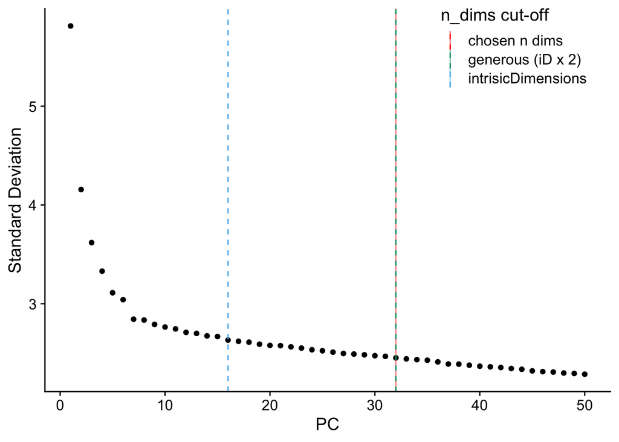

## Non-linear dimensionality reduction (UMAP, tSNE)